# High flow nasal oxygen during sedation in the cardiac catheterisation laboratory

A randomized controlled trial

Aaron Conway https://www.aaronconway.info (University of Toronto) , Peter Collins (Toronto General Hospital) , Kristina Chang (Toronto General Hospital) , Navpreet Kamboj (Toronto General Hospital) , Ana Lopez-Filici (Toronto General Hospital) , Matteo Parotto (Toronto General Hospital)

### Abstract

> **Background**

> High flow nasal oxygen (HFNO) permits flows of heated, humidified gas via nasal prongs at up to 70 liters per minute. Delivering oxygen at such high flow rates has multiple physiological effects that may better support the vulnerable breathing state of patients during procedural sedation. The objective of this study was to investigate the effects of HFNO in comparison to standard facemask oxygen during cardiac implantable electronic device (CIED) procedures performed with procedural sedation.

> **Results**

> The difference in peak TcCO<sub>2</sub> between groups was estimated to be 0.0mmHg (95% CI = -1.34 to 1.38). The estimated effect did not exceed the clinical significance threshold in either direction with high probability and there was no discernable trend observed in how the effect varied with procedure time. Particpants rated their satisfaction with sedation similarly between groups (0.0; 95% CI = -0.33 to 0.23). The probability that patients are more likely to rate comfort with the oxygen supplementation device higher with HFNO compared to the facemask is 0.70. The odds of Anesthesia Assistants being more likely to rate the use of the oxygen supplementation device as more easy to use in the facemask group was estimated to be 3 times that of the HFNO group (95% CI = 1 to 7 times). The odds of Anesthesia Assistants being more likely to rate their ability to maintain oxygen saturations as easy in the facemask group was 10 times that of the HFNO group (95% CI = 3 to 20 times). Minor adverse sedation events related to airway and breathing were 6.4 times more likely to occur in the HFNO group, but this estimate is imprecise (1.3 times to 43 times more likely).

> **Conclusion**

> There is no clear advantage for using HFNO in preference to facemask oxygen during CIED procedures performed with sedation.

## Introduction

Cardiac implantable electronic device (CIED) procedures are commonly performed with procedural sedation.<sup>1</sup> Prophylactic oxygen supplementation is usually administered to reduce risk of hypoxemia arising from sedation-induced hypoventilation and apnea.<sup>2,3</sup> High flow nasal oxygen (HFNO) is a promising device for oxygen supplementation in critical care and anesthesia.<sup>4</sup> HFNO devices allow for heated, humidified gas with a titratable oxygen:air ratio to be administered via nasal prongs at up to 70 liters per minute. Delivering oxygen supplementation at such high flow rates has multiple physiological effects that may better support the vulnerable breathing state of patients during procedural sedation compared with the standard approach, which is typically a facemask or nasal cannula. In particular, one of the proposed physiological effects of HFNO is that it facilitates active gas exchange during times of apnea due to the highly turbulent supraglottic flow vortices.<sup>5</sup> The effects of the potential disadvantages of using HFNO during sedation should also be evaluated. It is possible that the potential gains arising from delivering oxygen supplementation through the HFNO device may be offset by reduced ability to monitor ventilation from capnography waveforms when it is being used due to exhaled carbon dioxide concentrations being “washed out” by the high flows of gas. Furthermore, recent guidelines from the American Society of Anesthesiology have stated that there is insufficient evidence regarding which methods of supplemental oxygen administration (e.g., nasal cannula, face mask, or specialized devices such as HFNO) are more effective.<sup>6</sup> The objective of this study was to investigate the effects of HFNO in comparison to standard facemask oxygen during cardiac implantable electronic device procedures performed with procedural sedation.

## Methods

### Design

A randomized controlled trial design was used with participants randomized in a 1:1 ratio to the following treatment conditions:

- Oxygen supplementation through a standard facemask; or
- High flow nasal oxygen.

### Participants

Adults undergoing an elective cardiac implantable electronic device procedure with sedation administered by an Anesthesia Assistant (de novo and replacement/revision procedures) were included. As per the hospital’s policy for conscious sedation administered by Anesthesia Assistants, these patients were determined by the Anesthesiologist to be appropriate to receive care from the Anesthesia Assistants.

*Exclusion criteria*

1. Under 16 years of age.
2. Underlying condition requiring chronic oxygen supplementation.
3. Diagnosed respiratory condition with confirmed current hypercapnia defined as confirmed PaCO<sub>2</sub> during current admission over 45mmHg.
4. Pre-existing untreated pneumothorax.
5. Transesophageal echocardiography planned for the procedure.
6. Active nasal bleeding.
7. Complete nasal obstruction.
8. Recent upper airway surgery or base of skull fracture.
9. Previous participation in the study.

### Interventions

All randomized participants received usual care in regard to the medications used for sedation and physiological monitoring or other interventions to support respiratory function that are considered necessary to be initiated during the procedure by the clinicians. As per the hospital policy for sedation administered by Anesthesia Assistants, oxygen therapy is administered as indicated and prescribed to maintain oxygen saturation greater than 93%. In this study, Anesthesia Assistants followed this policy. Also in accordance with this hospital policy, the Anesthesia Assistants administer a combination of sedation to target the level of conscious sedation, which is defined as “A drug-induced depression of consciousness during which patients respond purposefully to verbal commands, either alone or accompanied by light tactile stimulation.” As such, by practicing in accordance with this hospital policy, the level of sedation being administered by the Anesthesia Assistant for participants included in this trial was ‘standardized’. The hospital policy does not stipulate any dose ranges of the different classes of sedative medications to be used and there were no restrictions on the type or dose of sedation used by Anesthesia Assistants as part of this trial. The actual doses of sedation were recorded. Only the device used for oxygen supplementation delivery differed between groups in the following ways:

**Facemask oxygen supplementation**

Supplemental oxygen through a facemask with the flow rate chosen by the clinician responsible for sedation as per their standard practice.

**High flow nasal oxygen**

The Optiflow device (Fisher and Paykel Healthcare, Auckland, New Zealand), heated breathing tube and chamber, and nasal cannula was used. This system is a humidifier with an integrated flow generator, able to humidify respiratory gases and deliver them down a heated breathing tube and through the nasal cannula interface. The gas temperature was set to the ‘High’ setting (ranges 30-32º Celsius) and titrated downwards if the patient complained of irritation. The gas flow rate was commenced at 30 liters per minute prior to sedation administration and titrated up to 50 liters per minute as tolerated by the patient after sedative medication was administered. The fraction of oxygen in the gas was commenced at 50% but could be titrated according to patient requirements (i.e. increased if there is evidence of hypoventilation, airway obstruction or inadequate oxygenation, decreased during use of diathermy). Anesthesia Assistants at the site were provided with training in the use of this mode of oxygen delivery prior to study commencement by the research team.

**Concomittant care**

There were no restrictions on concomittant care. For examle, Anesthesia Assistants were permitted to use whichever devices for physiological monitoring that they deemed were required and titrate sedation according to their usual practice. For ventilation monitoring, Anesthesia Assistants elected to use capnography regardless of whether supplemental oxygen was delivered via HFNO or a standard facemask. The standard facemask had an integrated CO<sub>2</sub> sampling line that could be connected to the the sidestream capnography sampling port of the anesthesia machine. For participants randomized to HFNO, Anesthesia Assistants were able to use the integrated CO<sub>2</sub> sampling adapter in the latest model of the HFNO nasal cannula for the majority of patients (all those recruited after September 2019). Prior to this newest model being available, Anesthesia Assistants used capnography to monitor ventilation by placing a facemask with an integrated CO<sub>2</sub> sampling line over the HFNO nasal cannula. Oxygen supplementation was delivered through the HFNO nasal cannula and CO<sub>2</sub> was sampled from the sampling line integrated into the facemask.

### Outcomes

The selection of outcomes was informed by recommendations from the Sedation Consortium on Endpoints and Procedures for Treatment, Education and Research (SCEPTER) to assess differences between groups regarding the safety and efficacy of sedation.<sup>7,8</sup>

The primary outcome was peak transcutaneous carbon dioxide ( TcCO<sub>2</sub>) concentration. Secondary outcomes were:

1. Mean transcutaneous carbon dioxide concentration measured throughout the whole procedure using the VSign 2 sensor.
2. Trajectory of transcutaneous carbon dioxide concentration as a function of time throughout the whole procedure using the VSign 2 sensor.
3. Area under the curve of oxygen desaturation: This is a composite measure comprising the incidence, depth, and duration of oxygen desaturation events. It is calculated as the difference between the threshold (90%) and actual oxygen saturation (SpO<sub>2</sub>) summed every minute during which oxygen saturation was below threshold).
4. Adverse sedation events: measured using the Tracking and reporting outcomes of procedural sedation (TROOPS) tool at the end of procedures.
5. Patient satisfaction with sedation: The Iowa Satisfaction with Anesthesia Scale (ISAS) will be used to measure patient satisfaction with the anesthetic used during the procedure performed.
6. Patient comfort of oxygen delivery: Participants will be asked to rate at the end of procedures their perceived overall comfort with the oxygen delivery device used during the procedure using a 6-level ratings scale.
7. Anesthesia Assistant rating of difficulty maintaining oxygenation status.
8. Anesthesia Assistant rating of difficulty using oxygen delivery device.

### Data collection

#### Instruments

Transcutaneous carbon dioxide concentrations were measured continuously using the Sentec Digital Monitoring system with VSign 2 sensor. TcCO<sub>2</sub> monitoring provides continuous, accurate (mean bias -0.1 mmHg) and precise (95% limits of agreement within 6 mmHg) estimates of arterial CO<sub>2</sub> (PaCO<sub>2</sub>) when the sensor is placed on the earlobe.<sup>9</sup> TcCO<sub>2</sub> monitoring may provide even more precise estimates of changes in PaCO<sub>2</sub> (mean bias 0.03 mmHg, 95% limits of agreement -0.44 to 0.38 mmHg).<sup>10</sup> The RA attached the Sentec VSign 2 sensor to the participant’s forehead using a multi-site attachment ring. Once the Sentec Digital Monitoring System displayed a stabilized TcCO<sub>2</sub> level, the monitor was covered with a drape so that it was not visible to research staff or clinicians. The monitor was not used by the clinicians to guide treatment. Data were downloaded after procedures for analysis.

Percentage of hemoglobin saturated with oxygen (SpO<sub>2</sub>) was collected as part of routine practice. The recorded SpO<sub>2</sub> was extracted from the Drug Reconciliation and Electronic Monitoring System at a frequency of one measurement per minute throughout procedures.

Adverse sedation events were measured using the tracking and reporting outcomes of procedural sedation (TROOPS) tool.<sup>11</sup> Completion of the tool requires identification and description of the adverse event, the intervention, the outcome and the overall severity of the adverse event. The Anaesthesia Assistant completed this tool at the end of procedures.

Satisfaction with sedation was measured using the Iowa Satisfaction with Anesthesia Scale (ISAS). The ISAS is a questionnaire that can be used to measure patient satisfaction with the anesthetic used during a procedure performed with sedation.<sup>12,13</sup> It contains 11 items and takes 4-5 minutes to complete. Comfort associated with oxygen delivery: Participants were asked to rate at the end of procedures their perceived overall comfort with the oxygen delivery device used during the procedure using a 6-level rating scale with ratings of ‘maximal discomfort’, ‘very uncomfortable’, ‘uncomfortable’, ‘comfortable’, ‘very comfortable’ and ‘maximal comfort’.

Adverse effects of delivering gas at a high flow rate through the nasal passages was assessed. The RA inspected intervention group participants’ skin integrity around the nasal region at the end of procedures to assess for these potentially anticipated as well as unanticipated adverse effects.

Anaesthesia Assistants were asked to rate their: 1) perceived level of difficulty in maintaining oxygenation using a 6-level rating scale with ratings of ‘extremely difficult’, ‘very difficult’, ‘difficult’, ‘easy’, ‘very easy’, ‘extremely easy’; and 2) perceived level of difficulty using the oxygen delivery device: The Anaesthesia Assistant will be asked to rate their perceived level of difficulty using the oxygen delivery device using a 6-level rating scale with ratings of ‘extremely difficult’, ‘very difficult’, ‘difficult’, ‘easy’, ‘very easy’, ‘extremely easy’.

Supplemental oxygen use and flow settings were documented by Anesthesia Assistants in a case report form provided to them by the Research Assistant. Information on the FiO2 setting, flow rate and temperature were recorded in the HFNO group. The oxygen flow rate was recorded in the control group. The Anesthesia Assistant also recorded the total doses of sedative medications used during procedures.

### Sample size calculation

We estimated based on data from our prior work<sup>2</sup> that the peak TcCO<sub>2</sub> level in the control group will be 47 mmHg and standard deviation in both groups will be 7 mmHg. Assuming a type I error rate of 5%, a sample of 130 participants would achieve 90% power to detect a reduction in mean TcCO<sub>2</sub> levels of 4 mmHg in the intervention period. A difference in TcCO<sub>2</sub> levels of 4 mmHg was selected for this sample size calculation because it was used to power previous randomized controlled trials of the effect of oxygen supplementation on ventilation status in other populations, with the authors noting that an effect of this magnitude was of physiological significance.<sup>14,15</sup> Also, differences in CO<sub>2</sub> levels of a similar magnitude have been detected in previous trials evaluating the efficacy of interventions to improve sedation safety.<sup>16–20</sup>

### Statistical analyses

All outcomes were analysed using Bayesian statistical models. Results from Bayesian models including 95% credible intervals are far easier to interpret than frequentist confidence intervals and p-values. Data and code required to reproduce the analyses is available to access in the [online supplementary information](https://hfnosedrct-dashboard.netlify.app). A detailed summary of the statistical models, including their prior specifications, is presented in the Appendix. Prior distributions were chosen to be weakly informative in the absence of information concerning the likely values of model parameters<sup>21</sup>.

The primary outcome, peak TcCO<sub>2</sub>, was compared between groups using a robust regression model. Covariate adjustments for the stratification variables obstructive sleep apnea (OSA) status and whteher or not the procedure was a cardiac resynchronization therapy (CRT) device implant were made in all models. Baseline TcCO<sub>2</sub> concentration is included as a covariate in the TcCO<sub>2</sub> models, as is recommended for this type of design, and it is modelled using splines.<sup>22</sup> A subgroup analysis was performed by expanding the model to include treatment interactions with the covariates OSA and CRT. The results of the subgroup analysis were compared to those from the primary analysis with only main effects to investigate the robustness of the conclusions to model specification.

The secondary outcome mean TcCO<sub>2</sub> concentration was analysed using the same model used to analyze peak TcCO<sub>2</sub>. A functional analysis of variance (ANOVA) model was used to further investigate how mean TcCO<sub>2</sub> concentration levels differ between groups as a function of procedure time<sup>23</sup>. The remaining continuous outcomes, average ISAS score and SpO<sub>2</sub> AUC, were analyzed using a robust regression model with covariate adjustments for OSA and CRT status.

Logistic regression model were used to analyze both the occurence of at least one adverse sedation event during a procedure, measured using the TROOPS tool, and the occurence of at least one desaturation event during a procedure, defined as instances where SPO<sub>2</sub> falls below a 90% threshold. A proportional-odds model was used for ordinal outcomes including participant ratings of comfort with the supplemental oxygen device, and Anesthesia Assistant ratings for difficulty maintaining oxygenation status and their rating of difficulty using supplemental oxygen device. The secondary outcome of mean TcCO<sub>2</sub> was compared between the intervention and control groups using a Bayesian one-way functional analysis of variance (ANOVA) model.

In the case of missing outcome data, we first assumed the data to be missing completely at random (MCAR)<sup>26</sup> and inference was performed using a complete-case analysis. When the proportion of missing data was large and the MCAR assumption was unlikely to be satisfied, a sensitivity analysis was performed to investigate the robustness of the conclusions of the complete-case analysis.

## Results

### Participants

A CONSORT flow diagram is presented in Figure 1. From August 2019 to March 2020, we screened 270 patients undergoing CIED procedures. A total of 130 participants were randomized. Although we initially planned (as outlined in the protocol) to recruit up to 150 patients, the decision was made to complete recruitment due to the onset of clinical research restrictions at the institution in response to COVID-19. One participant was subsequently excluded from the study because their procedure was cancelled after the randomization was performed. One further participant, who was randomized to the HFNO group, had their procedure rescheduled to a time that the Research Assistant was not available. As such, this participant received oxygen via standard face mask and TcCO<sub>2</sub> data were not collected. For two participants, the TcCO<sub>2</sub> sensor failed to callibrate prior to commencement of the procedure, so they were not able to be included in the analyses for the TcCO<sub>2</sub> outcomes. Fourteen of the Anesthesia Assistants reported that it was the first time they had used HFNO. Most (n=29; 45%) reported having used HFNO between 2 and 5 times with only one reporting using the device more than 10 times.

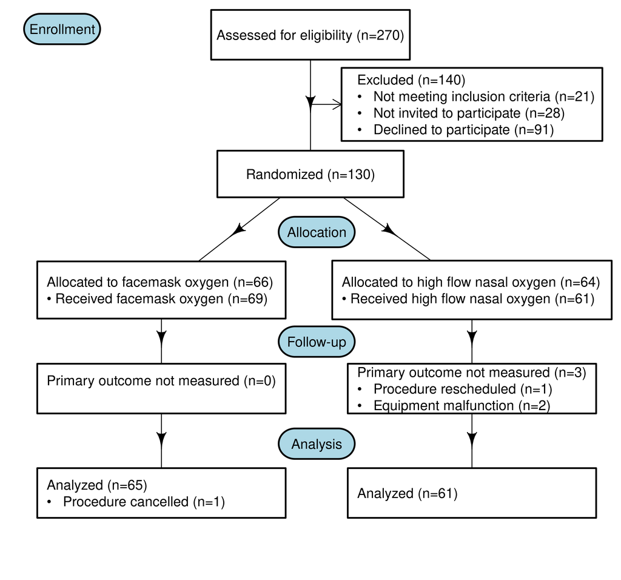

Figure 1: CONSORT flow diagram

A summary of demographic and clinical characteristics of the participants is presented in Table 1. The sample was mostly elder and male. Anesthesia Assistants’ rated the ASA Physical Classification Status for participants as either III or IV, reflecting the underlying cardiovascular disease and multiple comorbidities. Obstructive sleep apnea was common, with 27% of participants reporting a diagnosis of this condition. About 20% of procedures were for cardiac resnchronisation therapy.

##### Table 1. Participant Characteristics

| **Characteristic** | **High Flow nasal oxygen**, N = 64<sup>1</sup> | **Face mask oxygen**, N = 65<sup>1</sup> |
| --- | --- | --- |
| Age (years) | 67 (14) | 70 (13) |
| Gender |  |  |
| Female | 19 (30%) | 17 (26%) |
| Male | 45 (70%) | 47 (72%) |
| Prefer not to say | 0 (0%) | 1 (1.5%) |
| Other | 0 (0%) | 0 (0%) |
| Smoking history |  |  |
| Never | 23 (36%) | 25 (38%) |
| Current | 7 (11%) | 7 (11%) |
| Past | 34 (53%) | 33 (51%) |
| Obstructive sleep apnea | 17 (27%) | 18 (28%) |
| Uses CPAP | 9 (14%) | 12 (18%) |
| Admission source |  |  |
| Ward | 17 (27%) | 18 (28%) |
| Day surgery | 45 (70%) | 44 (68%) |
| CVICU | 2 (3.1%) | 3 (4.6%) |
| CICU | 0 (0%) | 0 (0%) |
| ASA classification status |  |  |
| I | 0 (0%) | 0 (0%) |
| II | 0 (0%) | 0 (0%) |
| III | 21 (33%) | 16 (25%) |
| IV | 43 (67%) | 49 (75%) |
| Procedure |  |  |
| PPM | 11 (17%) | 17 (26%) |
| PPM generator change | 6 (9.4%) | 7 (11%) |
| PPM lead revision | 0 (0%) | 1 (1.5%) |
| ICD | 19 (30%) | 13 (20%) |
| ICD generator change | 10 (16%) | 13 (20%) |
| ICD lead revision | 2 (3.1%) | 0 (0%) |
| CRT-D | 11 (17%) | 11 (17%) |
| CRT-P | 2 (3.1%) | 2 (3.1%) |
| Wound revision | 0 (0%) | 0 (0%) |
| Other | 3 (4.7%) | 1 (1.5%) |
| Charlson Comorbidity Index | 4.46 (2.14) | 5.15 (2.51) |
| Total dose of midazolam (mg) | 1.58 (0.84) | 1.45 (0.71) |
| Total dose of propofol (mg) | 100 (126) | 88 (104) |
| Total dose of fentanyl (mcg) | 71 (28) | 76 (56) |

<sup>*1*</sup> Statistics presented: mean (SD); n (%)

### Comparisons between groups

#### Primary outcome

Results of comparisons between HFNO and facemask oxygen are presented in Table 2. TcCO<sub>2</sub> concentrations for all patients throughout procedures are displayed in Figure 2, with the longest procedure highlighted as a reference. The effect of HFNO on the peak TcCO<sub>2</sub> was estimated to be 0.0mmHg (95% CI = -1.34 to 1.38). The probability that it exceeds the 4 mmHg clinical significance threshold of 4mmHg in either direction is 0. The estimates for the treatment effect in the baseline, OSA, and CRT subgroups when treatment interactions were included in the model did not exceed the clinical significance threshold in either direction with probability greater than 95%. Results for subgroup analyses are available in the [online supplementary information](https://hfnosedrct-dashboard.netlify.app).

##### Table 2. Results of intention-to-treat analyses

| Outcome | Summary value | Randomization Face mask oxygen | Randomization High flow nasal oxygen | Effect type | Estimated treatment effect (95% CI) |  |  |
| --- | --- | --- | --- | --- | --- | --- | --- |
| Peak TcCO<sub>2</sub> | N | 65 | 61 |  |  |  |  |
|  | Mean (sd) | 49.0 mmHg (6.9) | 47.8 mmHg (9.7) | Absolute difference | 0.0 mmHg (-1.34, 1.38) |  |  |
| Mean TcCO<sub>2</sub> | N | 65 | 61 |  |  |  |  |
|  | Mean (sd) | 44.3 mmHg (5.9) | 42.7 mmHg (7.2) | Absolute difference | -0.1 mmHg (-1.36, 1.17) |  |  |
| SpO<sub>2</sub> | N | 65 | 64 |  |  |  |  |
|  | SpO<sub>2</sub> <90% event | 7 (11%) | 8 (12%) | Odds ratio | 1.2 (0.37, 3.75) |  |  |
|  | Median (IQR) Area under SpO<sub>2</sub> desaturation curve | 8 (3.5, 9.5) | 9.5 (5.75, 25.25) |  |  |  |  |
| ISAS score | N | 63 | 63 |  |  |  |  |
|  | Mean (sd) | 2.1 (0.9) | 2.0 (1.0) | Absolute difference | 0.0 (-0.33, 0.23) |  |  |
| Patient comfort | N | 65 | 63 |  |  |  |  |
|  | Maximal comfort | 17 | 9 | Odds ratio | 1.2 (0.64, 2.17) |  |  |
|  | Very comfortable | 13 | 26 |  |  |  |  |
|  | Comfortable | 22 | 22 |  |  |  |  |
|  | Uncomfortable | 10 | 3 |  |  |  |  |
|  | Very uncomfortable | 2 | 2 |  |  |  |  |
|  | Maximal discomfort | 1 | 1 |  |  |  |  |
| Difficulty maintaining oxygenation status | N | 31 | 52 |  |  |  |  |
|  | Extremely easy | 17 | 9 | Odds ratio | 0.1 (0.05, 0.31) |  |  |
|  | Very easy | 10 | 14 |  |  |  |  |
|  | Easy | 4 | 17 |  |  |  |  |
|  | Difficult | 0 | 6 |  |  |  |  |
|  | Very difficult | 0 | 4 |  |  |  |  |
|  | Extremely difficult | 0 | 2 |  |  |  |  |
| Difficulty using oxygen delivery device | N | 32 | 52 |  |  |  |  |
|  | Extremely easy | 17 | 15 | Odds ratio | 0.3 (0.14, 0.83) |  |  |
|  | Very easy | 9 | 17 |  |  |  |  |
|  | Easy | 6 | 20 |  |  |  |  |
| Minor airway or breathing event | N | 65 | 64 |  |  |  |  |
|  | Yes | 2 | 9 | Odds ratio | 6.4 (1.34, 42.99) |  |  |
|  | No | 63 | 55 |  |  |  |  |

Odd ratios are interpreted as the odds of the event occuring in the HFNO group compared with the odds of the event occuring in the facemask group.  
TcCO<sub>2</sub> = Transcutaneous carbon dioxide concentration  
SpO<sub>2</sub> = Percentage of hemoglobin saturate with oxygen  
ISAS = Iowa Satisfaction with Anesthesia Scale  
95% CI = 95% credible intervals

#### Secondary outcomes

The effect of high flow nasal oxygen on the mean TcCO<sub>2</sub> concentration of the whole procedure was estimated to be -0.1 mmHg (-1.36, 1.17). The probability that it exceeds the 4 mmHg clinical significance threshold is again 0 in either direction. Differences in TcCO<sub>2</sub> concentration level between groups over time is presented in Figure 2. The estimated effect did not exceed the 4 mmHg clinical significance threshold in either direction with probability greater than 0.95 and there is no discernable trend observed in how the effect varies with procedure time. Precision decreases as procedure time increases, reflecting the shrinking number of participants to compare at those times.

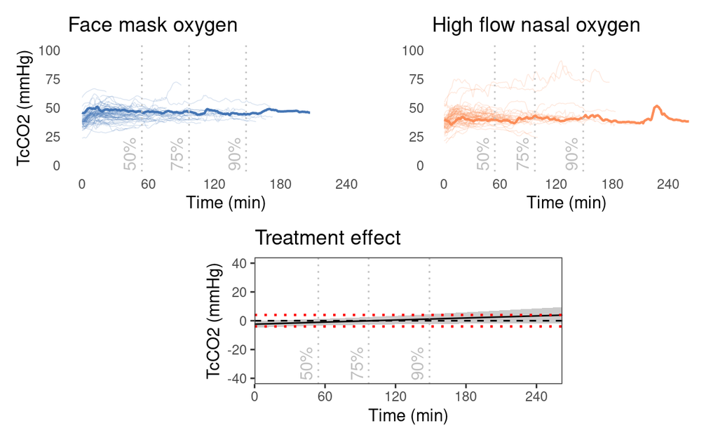

Figure 2: Transcutaneous carbon dioxide measurements throughout procedures

The odds ratio for a minor adverse airway or breathing outcome, as measured by the TROOPS tool, for the HFNO group compared with the facemask group was estimated to be 6.4. This effect estimate is very imprecise due to the small number of events (95% CI 1.3 to 43).

The effect of HFNO on average ISAS score was estimated to be 0.0 (95% CI = -0.33 to 0.23), where the effect is measured in units of absolute difference. Average ISAS scores from two participants were not calculated due to missing responses for at least one of the component ISAS items.

The odds ratio for Anesthesia Assistant ratings of difficulty maintaining oxygenation status and difficulty using the oxygen delivery device as estimated using a complete-case analysis are 0.1 (95% CI = 0.05 to 0.31) and 0.3 (95% CI = 0.14 to 0.83), where a value less than 1 indicates a greater level of difficulty for respondents in the HFNO group. It may be simpler for interpretation to reverse the terms. For example, the odds of Anesthesia Assistants being more likely to rate the use of the oxygen supplementation device as more easy to use (i.e., “extremely” or “very easy” versus “easy”) in the facemask group was estimated to be 3 times [i.e., 1/0.33] that of the HFNO group. The odds of Anesthesia Assistants being more likely to rate their ability to maintain oxygen saturations as easy in the facemask group was 10 times [i.e., 1/0.1] that of the HFNO group. It should be noted, however, that the Anesthesia Assistant ratings of difficulty using the oxygen device and difficulty maintaining oxygenation were missing 45 and 46 responses, respectively, likely due to the survey being voluntary. It is unlikely that missingness among these ratings occurred completely at random, so a best- and worst-case imputation approach was used to investigate the impact that the missing data could have on the results in extreme cases. The best- and worst-case sensitivity analysis gave estimates ranging between 0.0 (95% CI = 0.01 to 0.08) and 3.3 (95% CI = 1.72 to 6.62) for difficulty maintaining oxygenation status and from 0.1 (95% CI = 0.04 to 0.18) and 5.0 (95% CI = 2.49 to 9.79) for difficulty using the oxygen delivery device. These estimates suggest the directionality of the effect could be positive or negative with high probability, so conclusions of the complete-case analysis are not robust to assumptions about the values for the missing data.

The effect estimate for the absolute difference in the area under the SpO<sub>2</sub> desaturation curve was imprecise, spanning from 5 minutes.% higher in the face mask group to 24 minutes.% higher in the HFNO group. The probabity that the AUC<sub>DESAT</sub> was higher in the HFNO group was 0.83. A similar number of participants in the high flow nasal oxygen group (n=8; 12%) experienced an oxygen desaturation event in comparison with the facemask oxygen group (n=7; 11%), which was defined as a measurement below 90% (OR 1.2; 95% CI = 0.37 to 3.75). The probability that the odds of oxygen desaturation was higher in the HFNO group was 0.61 A visualization of the SpO<sub>2</sub> trajectories for patients whose SpO<sub>2</sub> was below 90% is available in the [online supplementary information](https://hfnosedrct-dashboard.netlify.app).

#### Oxygen flow rates

Participants randomized to the HFNO group received flow rates at 50 litres per minute or higher for the majority of the time (Figure 3). Two participants who were randomized to HFNO did not receive this intervention at all during procedures at the discretion of the Anesthesia Assistant, with the rationale that the high flow of oxygen interfered with capnography monitoring. Four participants who were randomized to HFNO stopped receiving this intervention at a certain timepoint during procedures at the discretion of the Anesthesia Assistant, again with the rationale that capnography monitoring was not sufficient with the HFNO device.

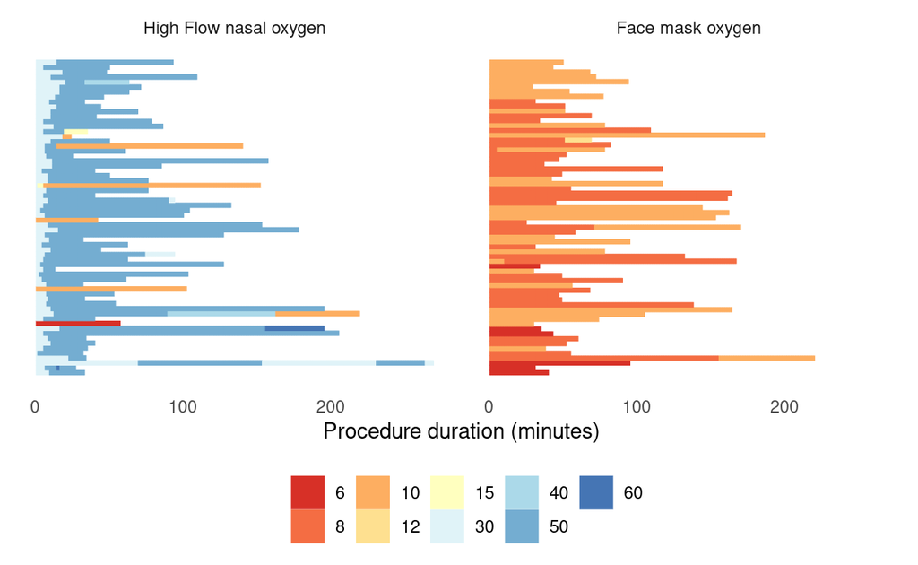

Figure 3: Oxygen flow rate in litres per minute for each participant

## Discussion

The primary result of this trial is that HFNO at 50 litres per minute for patients undergoing elective CIED procedures with sedation is highly unlikely to *decrease* or *increase* peak TcCO<sub>2</sub> concentration by a clinically important amount. Although a prior physiological modelling study identified a mechanism by which HFNO promotes carbon dioxide clearance,<sup>5</sup> it seems the magnitude of any such effect was insufficent to produce an important difference in ventilation status during procedural sedation. This result is consistent with prior clinical research in the non-sedation context. The difference in PaCO<sub>2</sub> observed between HFNO (5.81 kPa; sd=1.1) and standard facemask oxygen (5.6 kPa; sd=1.0) from a randomized trial of 20 patients who were receiving pre-oxygenation for induction of anesthesia prior to emergency surgery was not significant (p=0.631).<sup>27</sup> Likewise, in a larger trial of pre-oxygenation with 80 patients, the end-tidal CO<sub>2</sub> in the first breath after intubation was not significantly different between HFNO (5.0 kPa; sd=0.8) and standard facemask (5.3 kPa sd=1.0) oxygen supplementation (p=0.18).<sup>28</sup> Importantly, in contrast to these trials where ventilation status was assessed at one specific point in time with either PaCO<sub>2</sub> or ETCO<sub>2</sub> samples, we used continuous TcCO<sub>2</sub> monitoring so that we could estimate differences in ventilation between groups over the whole duration of procedures. There was no discernable trend observed in how the effect varied over time, lending strength to the assertion that ventilation status is not impacted by the use of HFNO. Based on the evidence at hand regarding the impact of HFNO on ventilation, we can infer that using this device during CIED procedures performed with procedural sedation is not likely to prevent potential adverse sedation events that may be precipitated by hypercarbia. In addition, authors of the physiological modelling study proposed that an improvement in oxygen transport would presumably go hand‐in‐hand with the enhancement of carbon dioxide clearance.<sup>5</sup> The lack of an important difference in TcCO<sub>2</sub> between groups in our study would suggest that the mechanism of any protective effects against hypoxemia during sedation that may be observed with the use of HFNO is therefore more likely to be due to superior pre-oxygenation rather than active gas exchange during hypoventilation.<sup>28,29</sup>

Capnography is widely considered to be an essential aspect of physiological monitoring during sedation.<sup>30–32</sup> One concern about using HFNO during sedation is that the ability to monitor capnography waveforms is diminished and, as a consequence, sedated patients may have more prolonged, undetected episodes of hypoventilation when it is used.<sup>33</sup> If this were the case, presumably we would have observed higher TcCO<sub>2</sub> concentrations in the HFNO group. We did not observe higher TcCO<sub>2</sub> concentrations in the HFNO group for the peak measurement or at any particular timepoint during procedures. Therefore, the use of HFNO during sedation should not be precluded solely on the basis that capnogrpahy monitoring is not effective when high flows of oxygen are being delivered.

Results of our study have revealed some interesting insights into the impact that using HFNO during sedation for CIED procedures has on patient-reported outcomes. Overall patient satisfaction with sedation is very likely to be similar regardless of the type of oxygen supplementation device used, with no difference observed between groups in ISAS scores. The probability that patients are more likely to rate comfort with the oxygen supplementation device higher with HFNO compared to the facemask was 0.70. As such, it is likely ther is not a negative impact on patient-reported outcomes associated with using HFNO during sedation.

In contrast to these mostly postive findings from the patient perspective, we identified that the HFNO device was rated as more difficult for Anesthesia Assistants to use compared with the standard facemask. However, it should be noted that none of the Anesthesia Assistants rated the HFNO device as *difficult* to use and most had very limited experience using the device. Most participants reported they had used HFNO between 2 and 5 times. Potentially, increased experience with HFNO would influence clinicians’ perceptions about the difficulty using the device in comparison to standard facemask oxygen.

Participants in our study mostly received combinations of propofol, midazolam and fentanyl for sedation, which is a common and recommended regimen for CIED procedures.<sup>39</sup> There is the potential that different results may be observed for patients who receive higher doses of sedation or who experience more frequent or prolonged episodes of hypoventilation and apnea than those in our study. It should also be noted that participants randomized to HFNO received oxygen at flows at or exceeding 50 liters per minure for the majority of the time. Results could have differed if higher flow rates were used.

Oxygen desaturation is not a common event when oxygen supplementation at flow rates between 6-10 liters per minute through a face mask during procedures performed with sedation in the cardiac catheterisation laboratory.<sup>1,3</sup> Results from trials of HFNO during sedation conducted in other clinical settings, such as bronchoscopy and gastrointestinal endoscopy, where desaturation occurs more often, can therefore not be directly generalised to the cardiology context.

### Limitations

Ventilation status was measured using TcCO<sub>2</sub> monitoring, which is not a perfect substitute for PaCO<sub>2</sub>. The primary outcome was peak TcCO<sub>2</sub> and we accounted for the correlation between baseline and peak measurements by including the baseline measurements as a covariate in the model. However, an inherent problem with this approach is that it is potentially sensitive to how the baseline and peak measurements were chosen. We chose the TcCO<sub>2</sub> concentration at the time sedation was first administered as the baseline measurement and the maximimum TcCO<sub>2</sub> observed over the whole procedure as the peak. It is unknown if results are robust to a different baseline measurement, such as the average of a certain number of seconds around these timepoints.

A further potential limitation is that we did not blind participants or clinicians to group assignment. We included only patients undergoing elective CIED procedures. Extrapolation of our findings to other procedures performed in procedural settings or emergency procedures where the patient characteristics may be very different to our sample is not recommended. The small dropout and cross-over rate is unlikely to have exerted a major impact on our estimates of the effect of HFNO during CIED procedures performed with sedation. Based on the data collected about the oxygen device settings used in both HFNO (flow rate, oxygen:air blend) and facemask (flow rate) groups, we do not suspect there was any significant bias associated with suboptimal application of oxygen supplementation in either group.

### Conclusion

We identified no clear advantage for using HFNO in place of facemask oxygen during CIED procedures performed with sedation. Ventilation, as measured by TcCO<sub>2</sub> monitoring, did not differ by a clinically important amount between groups. There is a higher probability that patients will be more comfortable during procedures with HFNO in comparison to the facemask, but overall patient satisfaction with sedation was similar between groups. Anesthesia Assistants rated the HFNO device as more difficult to use than facemask oxygen.

1. Conway A, Rolley J, Page K, Fulbrook P. Trends in nurse-administered procedural sedation and analgesia across cardiac catheterisation laboratories in australia and new zealand: Results of an electronic survey. Australian Critical Care 2014;27:4–10.

2. Conway A, Collins P, Chang K, Mafeld S, Sutherland J, Fingleton J. Sequence analysis of capnography waveform abnormalities during nurse-administered procedural sedation and analgesia in the cardiac catheterization laboratory. Scientific Reports 2019;9. Available at: https://doi.org/10.1038/s41598-019-46751-2.

3. Conway A, Page K, Rolley J, Fulbrook P. Risk factors for impaired respiratory function during nurse-administered procedural sedation and analgesia in the cardiac catheterisation laboratory: A matched case–control study. European Journal of Cardiovascular Nursing 2013;12:393–9.

4. Drake MG. High-flow nasal cannula oxygen in adults: An evidence-based assessment. Annals of the American Thoracic Society 2018;15:145–55.

5. Hermez LA, Spence CJ, Payton MJ, Nouraei SAR, Patel A, Barnes TH. A physiological study to determine the mechanism of carbon dioxide clearance during apnoea when using transnasal humidified rapid insufflation ventilatory exchange (thrive). Anaesthesia 2019;74:441–9. Available at: https://doi.org/10.1111/anae.14541.

6. Apfelbaum J, Gross J, Connis R, Agarkar M, Arnold D, Coté C, Tung A. Practice guidelines for moderate procedural sedation and analgesia 2018: A report by the american society of anesthesiologists task force on moderate procedural sedation and analgesia, the american association of oral and maxillofacial surgeons, american college of radiology, american dental association, american society of dentist anesthesiologists, and society of interventional radiology. Anesthesiology 2018;128:437–79.

7. Williams MR, Ward DS, Carlson D, Cravero J, Dexter F, Lightdale JR, Mason KP, Miner J, Vargo JJ, Berkenbosch JW, Clark RM, Constant I, Dionne R, Dworkin RH, Gozal D, Grayzel D, Irwin MG, Lerman J, O’Connor RE, Pandharipande P, Rappaport BA, Riker RR, Tobin JR, Turk DC, Twersky RS, Sessler DI. Evaluating patient-centered outcomes in clinical trials of procedural sedation, part 1 efficacy: Sedation consortium on endpoints and procedures for treatment, education, and research recommendations. Anesthesia & Analgesia 2017;124:821–30. Available at: https://doi.org/10.1213/ane.0000000000001566.

8. Ward DS, Williams MR, Berkenbosch JW, Bhatt M, Carlson D, Chappell P, Clark RM, Constant I, Conway A, Cravero J, Dahan A, Dexter F, Dionne R, Dworkin RH, Gan TJ, Gozal D, Green S, Irwin MG, Karan S, Kochman M, Lerman J, Lightdale JR, Litman RS, Mason KP, Miner J, O’Connor RE, Pandharipande P, Riker RR, Roback MG, Sessler DI, et al. Evaluating patient-centered outcomes in clinical trials of procedural sedation, part 2 safety: Sedation consortium on endpoints and procedures for treatment, education, and research recommendations. Anesthesia & Analgesia 2018;127:1146–54. Available at: https://doi.org/10.1213/ane.0000000000003409.

9. Conway A, Tipton E, Liu W-H, Conway Z, Soalheira K, Sutherland J, Fingleton J. Accuracy and precision of transcutaneous carbon dioxide monitoring: A systematic review and meta-analysis. Thorax 2019;74:157–63.

10. Fingleton J, Mckinstry S, Pilcher J, Weatherall M, Beasley R, Bardsley G. Accuracy of transcutaneous carbon dioxide measurement for change over time. 2017;22:98.

11. Roback MG, Green SM, Andolfatto G, Leroy PL, Mason KP. Tracking and reporting outcomes of procedural sedation (troops): Standardized quality improvement and research tools from the international committee for the advancement of procedural sedation. British Journal of Anaesthesia 2018;120:164–72.

12. Dexter F, Aker J, Wright WA. Development of a measure of patient satisfaction with monitored anesthesia care the iowa satisfaction with anesthesia scale. Anesthesiology 1997;87:865–73.

13. Dexter F, Candiotti KA. Multicenter assessment of the iowa satisfaction with anesthesia scale, an instrument that measures patient satisfaction with monitored anesthesia care. Anesthesia & Analgesia 2011;113:364–8.

14. Perrin K, Wijesinghe M, Healy B, Wadsworth K, Bowditch R, Bibby S, Baker T, Weatherall M, Beasley R. Randomised controlled trial of high concentration versus titrated oxygen therapy in severe exacerbations of asthma. Thorax 2011;66:937–41.

15. Wijesinghe M, Perrin K, Healy B, Weatherall M, Beasley R. Randomized controlled trial of high concentration oxygen in suspected community-acquired pneumonia. Journal of the Royal Society of Medicine 2012;105:208–16.

16. Baulig W, Keselj M, Baulig B, Guzzella S, Borgeat A, Aguirre J. Transcutaneous continuous carbon dioxide tension monitoring reduced incidence, degree and duration of hypercapnia during combined regional anaesthesia and monitored anaesthesia care in shoulder surgery patients. Journal of Clinical Monitoring and Computing 2015;29:499–507.

17. Carmi U, Kramer MR, Zemtzov D, Rosengarten D, Fruchter O. Propofol safety in bronchoscopy: Prospective randomized trial using transcutaneous carbon dioxide tension monitoring. Respiration 2011;82:515–21.

18. De Oliveira Jr GS, Ahmad S, Fitzgerald PC, McCarthy RJ. Detection of hypoventilation during deep sedation in patients undergoing ambulatory gynaecological hysteroscopy: A comparison between transcutaneous and nasal end-tidal carbon dioxide measurements. British Journal of Anaesthesia 2010;104:774–8.

19. De Oliveira Jr GS, Fitzgerald PC, Hansen N, Ahmad S, McCarthy RJ. The effect of ketamine on hypoventilation during deep sedation with midazolam and propofol: A randomised, double-blind, placebo-controlled trial. European Journal of Anaesthesiology 2014;31:654–62.

20. Smith SB, Carr S, Psikula S, Das A, Grichnik K. A pilot study on the effect of nasal continuous positive airway pressure on arterial partial pressure of carbon dioxide during spinal anesthesia with intravenous sedation for total knee arthroplasty. Anesthesia & Analgesia 2015;120:479–83.

21. Gelman A, Jakulin A, Pittau MG, Su Y-S, others. A weakly informative default prior distribution for logistic and other regression models. The annals of applied statistics 2008;2:1360–83.

22. Egbewale BE, Lewis M, Sim J. Bias, precision and statistical power of analysis of covariance in the analysis of randomized trials with baseline imbalance: A simulation study. BMC Medical Research Methodology 2014;14:49.

23. Yue Y (Ryan), Bolin D, Rue H, Wang X-F. Bayesian generalized two-way anova for functional data using inla. Statistica Sinica 2019;29:741–67.

24. Bürkner P-C. Brms: An r package for bayesian multilevel models using stan. Journal of Statistical Software 2017;80:1–28.

25. Rue H, Martino S, Chopin N. Approximate bayesian inference for latent gaussian models by using integrated nested laplace approximations. Journal of the Royal Statistical Society 2009;71:319–92. Available at: http://myaccess.library.utoronto.ca/login?url=https://search-proquest-com.myaccess.library.utoronto.ca/docview/37127083?accountid=14771.

26. Gelman A, Carlin JB, Stern HS, Dunson DB, Vehtari A, Rubin DB. Bayesian data analysis, third edition. CRC Press, 2013.

27. Mir F, Patel A, Iqbal R, Cecconi M, Nouraei S. A randomised controlled trial comparing transnasal humidified rapid insufflation ventilatory exchange (thrive) pre-oxygenation with facemask pre-oxygenation in patients undergoing rapid sequence induction of anaesthesia. Anaesthesia 2017;72:439–43.

28. Lodenius Å, Piehl J, Östlund A, Ullman J, Jonsson Fagerlund M. Transnasal humidified rapid-insufflation ventilatory exchange (thrive) vs. Facemask breathing pre-oxygenation for rapid sequence induction in adults: A prospective randomised non-blinded clinical trial. Anaesthesia 2018;73:564–71.

29. Patel A, Nouraei S. Transnasal humidified rapid-insufflation ventilatory exchange (thrive): A physiological method of increasing apnoea time in patients with difficult airways. Anaesthesia 2015;70:323–9.

30. Conway A, Douglas C, Sutherland J. A systematic review of capnography for sedation. Anaesthesia 2016;71:450–4.

31. Conway A, Collins P, Chang K, Mafeld S, Sutherland J, Fingleton J, Parotto M. Pre-apneic capnography waveform abnormalities during procedural sedation and analgesia. Journal of Clinical Monitoring and Computing 2019:1–8.

32. Conway A, Rolley J, Page K, Fulbrook P. Clinical practice guidelines for nurse-administered procedural sedation and analgesia in the cardiac catheterization laboratory: A modified delphi study. Journal of advanced nursing 2014;70:1040–53.

33. Horiuchi A, Graham DY. High-flow nasal cannula oxygen therapy obscures severe respiration depression, providing an illusion of safety. Gastrointestinal Endoscopy 2020;91:720–1.

34. Lin Y, Zhang X, Li L, Wei M, Zhao B, Wang X, Pan Z, Tian J, Yu W, Su D. High-flow nasal cannula oxygen therapy and hypoxia during gastroscopy with propofol sedation: A randomized multicenter clinical trial. Gastrointestinal endoscopy 2019;90:591–601.

35. Eugene A, Fromont L, Auvet A, Baert O, Mfam W-S, Remerand F, Boulain T, Nay M-A. High-flow nasal oxygenation versus standard oxygenation for gastrointestinal endoscopy with sedation. The prospective multicentre randomised controlled odephi study protocol. BMJ open 2020;10.

36. Douglas N, Ng I, Nazeem F, Lee K, Mezzavia P, Krieser R, Steinfort D, Irving L, Segal R. A randomised controlled trial comparing high-flow nasal oxygen with standard management for conscious sedation during bronchoscopy. Anaesthesia 2018;73:169–76.

37. Riccio CA, Sarmiento S, Minhajuddin A, Nasir D, Fox AA. High-flow versus standard nasal cannula in morbidly obese patients during colonoscopy: A prospective, randomized clinical trial. Journal of Clinical Anesthesia 2019;54:19–24.

38. Sago T, Harano N, Chogyoji Y, Nunomaki M, Shiiba S, Watanabe S. A nasal high-flow system prevents hypoxia in dental patients under intravenous sedation. Journal of Oral and Maxillofacial Surgery 2015;73:1058–64.

39. Furniss SS, Sneyd JR. Safe sedation in modern cardiological practice. Heart 2015;101:1526–30.

40. Sørbye SH, Rue H. Scaling intrinsic gaussian markov random field priors in spatial modelling. Spatial Statistics 2014;8:39–51. Available at: http://www.sciencedirect.com/science/article/pii/S2211675313000407.

# Appendix

## Robust regression

A robust regression model is used for the analysis of continuous outcomes peak TcCO2, mean TcCO2, average SPO2, and average ISAS score. Let $y_i$ be the value of the continuous response for the $i$th patient, $x_{Baseline,i}$ be a baseline covariate, and $x_{HFNO,i}$ be an indicator variables which is nonzero if the patient belonged to the HFNO treatment group. Associated with each patient are additional stratification indicator variables for OSA status $x_{OSA,i}$ and CRT status $x_{CRT,i}$. We supress the patient index $i$ on patient covariates to simplify the notation.

where $f$ is a non-linear continuous function of a continuous covariate $x_{Baseline}$ and $\beta_j, j=0,1,2,3$, are regression coeficients. For peak and mean TcCO<sub>2</sub>, $x_{Baseline}$ is taken as the first recorded value of TcCO<sub>2</sub> of the patient during their procedure. For average SPO$_2$ and average ISAS score there is no corresponding baseline covariate and so $f$ is omitted. Prior distributions of model parameters are chosen to be diffuse in the absence of information about their likely values. In the following list of prior specifications, $\text{Normal}(\mu,\sigma)$ denotes a normal distribution with mean $\mu$ and standard deviation $\sigma$.

## Functional analysis of variance

The functional observations $\mathbf{y}_{ij}$ are taken to be the vector of TcCO<sub>2</sub> measurements of the $i$th patient belonging to randomization group $j$ measured at 1 second intervals from the procedure’s start until the procedure’s end. The group variable $j=1$ indicates membership to the face mask oxygen group and $j=2$ indicates membership to the high flow nasal oxygen group. Associated with each patient are stratification indicator variables for their OSA status $x_{OSA}$ and CRT status $x_{CRT}$. All functional observations are aligned to have time $t=0$ occur at the start of each procedure. The time resolution of observations is reduced to measurements every 30 seconds to reduce the computational burden of model fitting.

The one-way functional ANOVA model assumes that the TcCO<sub>2</sub> measurments $\mathbf{y}_{ij}$ for the $i$th patient has the likelihood function
$$\begin{equation}
y_{ij} | \boldsymbol{\eta}_{ij},\Sigma_i \sim \text{Normal}\left(\boldsymbol{\eta}_{ij}, \Sigma_i\right),
\end{equation}$$
where $\boldsymbol \eta_{ij}$ is the mean vector and $\Sigma_i$ is a covariance matrix. The mean vector is assumed to have the form
$$\begin{equation}
\boldsymbol\eta_{ij} = \boldsymbol\mu + \boldsymbol\alpha_j + \beta_1x_{OSA} + \beta_2x_{CRT} + b_i,
\end{equation}$$
where $\boldsymbol\mu$ is the baseline functional effect common to all patients, $\boldsymbol\alpha_j$ is the $j$th treatment group functional effect,$\beta_1$ and $\beta_2$ are effects for OSA status and CRT status, respectively. A normally-distributed random intercept $b_i \sim N(0,\sigma_b^2)$ is included to account for different average levels in TcCO<sub>2</sub> observed between patients. The baseline constraint parameterization of $\alpha_1 = 0$ is used to ensure that the model is identifiable. Under this parameterization, $\boldsymbol\mu$ is the mean level of TcCO<sub>2</sub> of the face mask oxygen group and $\boldsymbol\mu + \boldsymbol\alpha_2$ is the mean level of TcCO<sub>2</sub> of the high flow nasal oxygen group.

The set of TcCO<sub>2</sub> measurements from a patient form a time-series that is inadequately modelled by assuming independent and identically distributed normal errors in (3). Mis-specification of the covariance structure can lead to credible intervals for the treatment effect that are artificially narrow. To better model the error structure of the data, the covariance matrix $\Sigma_i$ is assumed to have the form of an autoregressive process of order 1 with the same set of correlation and variance parameters for every patient, denoted $\rho$ and $\sigma^2_{AR1}$, respectively.

The model is scaled to have generalized variance of 1 to aid in prior specification<sup>40</sup>. The prior distrbutions of model parameters are chosen to be diffuse in the absence of information about their likely values. They are as follows: